# House data

Arrolag

September 11, 2016

## Introduction

The purpose of this case study is to predict house prices in King County, USA, using various predictors as found in the kcc.csv data set.

## Data Source

The data set contains house-sale prices for King County, which includes Seattle. It includes homes sold between May 2014 and May 2015.

It was downloaded from https://www.kaggle.com/harlfoxem/housesalesprediction

## Description of the dataset

The dataset comprises of 21613 entries and 21 variables. The dependent variable is price.

```r
options(scipen = 999)
house <- read.csv("C:/Users/user/Desktop/Project/kc_house_data.csv", header = TRUE)
str(house)
```

```
'data.frame':   21613 obs. of  21 variables:
 $ id           : num  7129300520 6414100192 5631500400 2487200875 1954400510 ...
 $ date         : Factor w/ 372 levels "20140502T000000",..: 165 221 291 221 284 11 57 252 340 306 ...
 $ price        : num  221900 538000 180000 604000 510000 ...
 $ bedrooms     : int  3 3 2 4 3 4 3 3 3 3 ...
 $ bathrooms    : num  1 2.25 1 3 2 4.5 2.25 1.5 1 2.5 ...
 $ sqft_living  : int  1180 2570 770 1960 1680 5420 1715 1060 1780 1890 ...
 $ sqft_lot     : int  5650 7242 10000 5000 8080 101930 6819 9711 7470 6560 ...
 $ floors       : num  1 2 1 1 1 1 2 1 1 2 ...
 $ waterfront   : int  0 0 0 0 0 0 0 0 0 0 ...
 $ view         : int  0 0 0 0 0 0 0 0 0 0 ...
 $ condition    : int  3 3 3 5 3 3 3 3 3 3 ...
 $ grade        : int  7 7 6 7 8 11 7 7 7 7 ...
 $ sqft_above   : int  1180 2170 770 1050 1680 3890 1715 1060 1050 1890 ...
 $ sqft_basement: int  0 400 0 910 0 1530 0 0 730 0 ...
 $ yr_built     : int  1955 1951 1933 1965 1987 2001 1995 1963 1960 2003 ...
 $ yr_renovated : int  0 1991 0 0 0 0 0 0 0 0 ...
 $ zipcode      : int  98178 98125 98028 98136 98074 98053 98003 98198 98146 98038 ...
 $ lat          : num  47.5 47.7 47.7 47.5 47.6 ...
 $ long         : num  -122 -122 -122 -122 -122 ...
 $ sqft_living15: int  1340 1690 2720 1360 1800 4760 2238 1650 1780 2390 ...
 $ sqft_lot15   : int  5650 7639 8062 5000 7503 101930 6819 9711 8113 7570 ...
```

The following are descriptions of various attributes:

- sqft_living, the total house square footage of the house
- sqft_basement, size of the basement
- sqft_above = sqft_living - sqft_basement
- sqft_lot, lot size of the house
- sqft_living15, the average house square footage of the 15 closest houses
- sqft_lot15, the average lot square footage of the 15 closest houses

### Data cleaning

*date* is broken down into year, month and day of pricing. The three variables are then converted into factors.

*waterfront* is converted into a factor with 2 levels, 0 (No Waterfront) and 1 (Waterfront).

*view* is converted into a factor variable with 5 levels: 0, 1, 2, 3, 4.

*condition* is converted into a factor variable with 5 levels: 1, 2, 3, 4, 5.

*grade* is converted into a factor variable with 12 levels: 1, 3, 4, 5, 6, 7, 8, 9, 10, 11, 12, 13.

From *yr_built* we calculate the *age* of the house from year of sale.

From *yr_renovated* we derive a factor variable *renovated* with 2 levels: 0- not renovated, 1- renovated.

```r
require(lubridate)
require(dplyr)
house$date_year <- year(ymd_hms(house$date))
house <- mutate(house,age = date_year - yr_built)
house$date_year <- as.factor(house$date_year)
house$date_month <- as.factor(month(ymd_hms(house$date)))
house$date_day <- as.factor(day(ymd_hms(house$date)))
house$waterfront <- as.factor(house$waterfront)
house$view <- as.factor(house$view)
house$condition <- as.factor(house$condition)
house$grade <- as.factor(house$grade)
fac_fn <- function(x){
    if (x==0)
        return(0)
    else
        return(1)
}
house$renovated <- sapply(house$yr_renovated,fac_fn)
```

The data set is randomly divided into a training and testing set in the ratio 7:3

```r
dt = sort(sample(nrow(house), nrow(house)*.7))
train<-house[dt,]
test<-house[-dt,]
```

We then perform an analysis of variables within the training set

### Variable analysis

```r
table(subset(data.frame(table(train$id)), Freq > 1)$Freq)
```

```
##
##  2  3
## 87  1
```

#### Analysis of linear relationship between pairs of quantitative variables

We modify the correlation matrix (as given by R), so that the 1’s on the leading diagonal are replaced by the standard deviations for each variable. The upper triangle of the matrix is also replaced with the spearman’s correlation.

From the correlation matrix, the variables *sqft_living* and *bathrooms* have reasonably high correlations with the dependent variable, *price*. There seems to be almost no correlation between each of *sqft_lot15*, *age* and the dependent variable, *price*.

```r
train_reg <- select(train, price, bedrooms, bathrooms, sqft_living, sqft_lot, floors, waterfront, view, condition, grade, sqft_above, sqft_basement, sqft_living15, sqft_lot15,date_year, date_month, date_day, age, renovated)
num_columns <- c("price","sqft_living","sqft_lot","bedrooms","bathrooms","floors","sqft_above","sqft_basement","sqft_living15","sqft_lot15","age")
corr_a <- cor(train_reg[,num_columns])
corr_pear <- cor(train_reg[,num_columns],method = "spearman")
final_mat <- diag(sapply(train_reg[,num_columns],sd))+upper.tri(corr_pear)*corr_pear +lower.tri(corr_a)*corr_a
round(final_mat,digits = 2)
```

```
                  price sqft_living sqft_lot bedrooms bathrooms floors
price         366397.98        0.64     0.08     0.34      0.50   0.32
sqft_living        0.70      919.59     0.31     0.64      0.74   0.40
sqft_lot           0.10        0.18 41155.47     0.22      0.07  -0.24
bedrooms           0.30        0.57     0.04     0.94      0.52   0.22
bathrooms          0.53        0.75     0.09     0.51      0.77   0.54
floors             0.25        0.35    -0.01     0.17      0.50   0.54
sqft_above         0.60        0.88     0.19     0.47      0.69   0.52
sqft_basement      0.32        0.44     0.02     0.30      0.28  -0.25
sqft_living15      0.59        0.76     0.15     0.39      0.57   0.28
sqft_lot15         0.08        0.18     0.77     0.03      0.09  -0.02
age               -0.05       -0.31    -0.06    -0.15     -0.50  -0.49
              sqft_above sqft_basement sqft_living15 sqft_lot15   age
price               0.54          0.25          0.57       0.07 -0.10
sqft_living         0.84          0.33          0.75       0.29 -0.35
sqft_lot            0.28          0.04          0.36       0.92  0.04
bedrooms            0.54          0.23          0.44       0.21 -0.17
bathrooms           0.69          0.19          0.57       0.07 -0.56
floors              0.59         -0.27          0.30      -0.23 -0.56
sqft_above        827.66         -0.17          0.70       0.27 -0.47
sqft_basement      -0.05        442.99          0.13       0.03  0.18
sqft_living15       0.73          0.21        687.03       0.37 -0.33
sqft_lot15          0.19          0.02          0.18   28545.37  0.02
age                -0.42          0.14         -0.32      -0.07 29.28
```

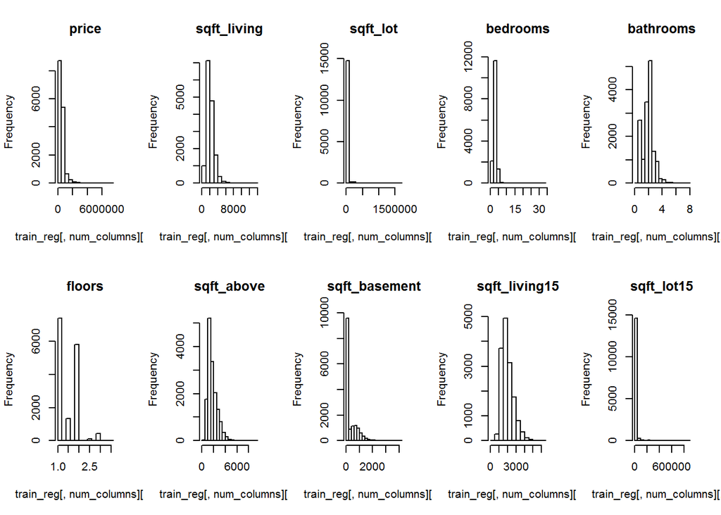

```r
par(mfrow=c(2,5))
for(i in 1:10) {
    hist(train_reg[,num_columns][,i], main=names(train_reg[,num_columns])[i])
}
```

From the histograms and boxplots, we observe that *price*, *sqft_living*, *sqft_lot*, *sqft_above*, *sqft_basement*, *sqft_living15* and *sqft_lot15* have many outliers to the right, hence are highly positively skewed.

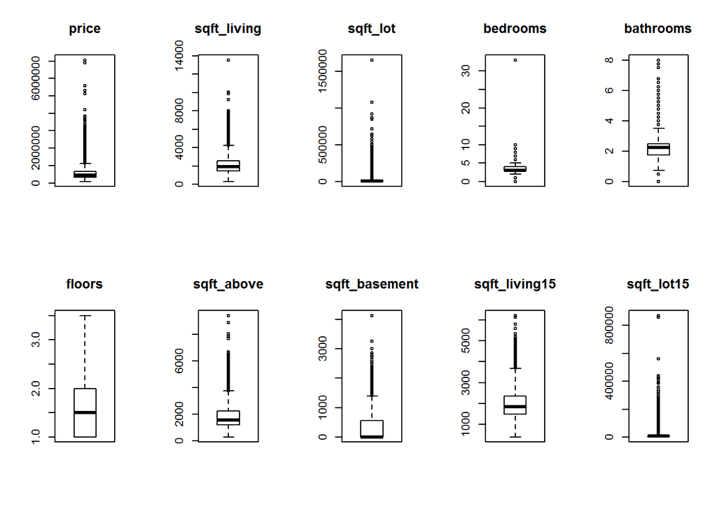

```r
par(mfrow=c(2,5))
for(i in 1:10) {
    boxplot(train_reg[,num_columns][,i], main=names(train_reg[,num_columns])[i])
}
```

We note that the response variable is heavily skewed to the right. The effect of this can be seen on the diagnostic plots done on the model containing only the continuous variables *fita*

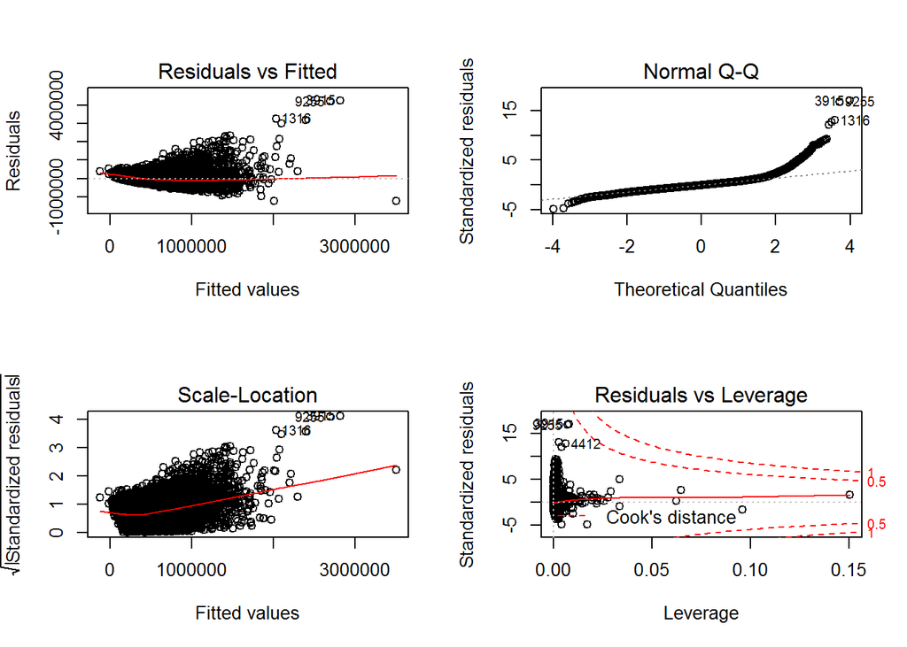

```r
cont_columns <-c("price","sqft_living","sqft_lot","sqft_above","sqft_basement","sqft_living15","sqft_lot15","age")
fita <- lm(price~., data = train_reg[,cont_columns])
par(mfrow=c(2,2))
plot(fita)
```

Further, plots of the residuals of *fita* against each one of the continuous predictors together with lowess curves are drawn. From this, we observe that *sqft_living*, *sqft_lot*, *sqft_basement* and *sqft_lot15* do not exhibit linearity. To improve this fit, we perform a logarithmic transformation on the dependent variable.

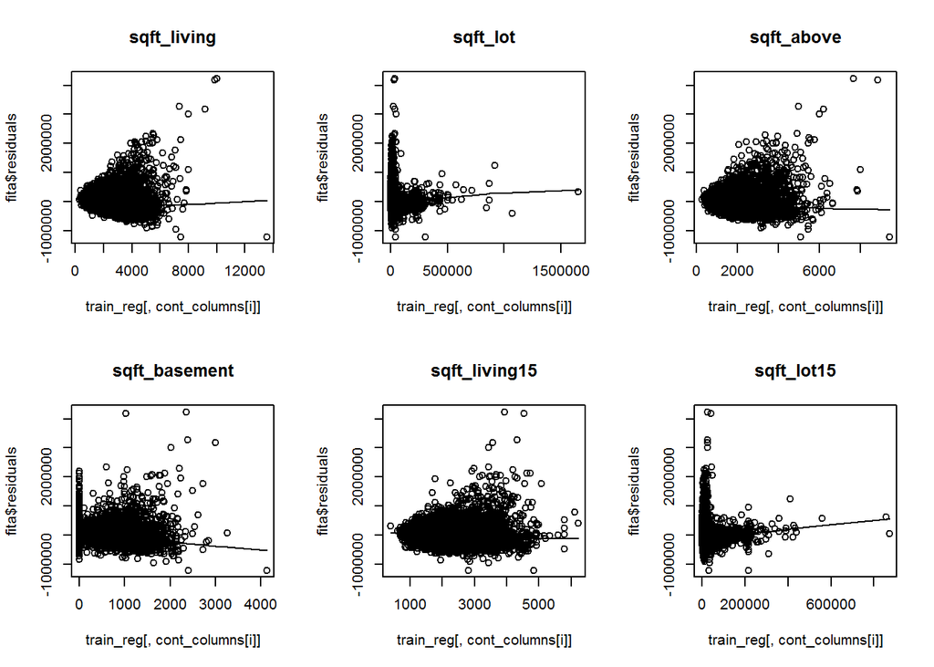

```r
par(mfrow=c(2,3))
for(i in 2:7) {
    plot(train_reg[,cont_columns[i]], fita$residuals, main = names(train_reg[,cont_columns])[i])
    lines(lowess(train_reg[,cont_columns[i]], fita$residuals))
}
```

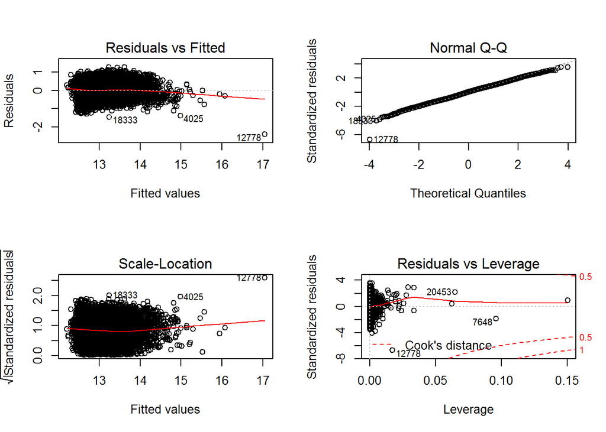

```r
cont_columnsb <-c("log_price","sqft_living","sqft_lot","sqft_above","sqft_basement","sqft_living15","sqft_lot15","age")
train_reg$log_price <- log(train_reg$price)
test$log_price <- log(test$price)
fitb <- lm(log_price~., data = train_reg[,cont_columnsb])
par(mfrow=c(2,2))
plot(fitb)
```

QQ plots of the transformed model *fitb* reveal normal residuals. The lowess fit line in the residuals vs fitted values plot also does not show a large deviation from the zero-line. This means that the transformed model better specifies the relationship between the variables.

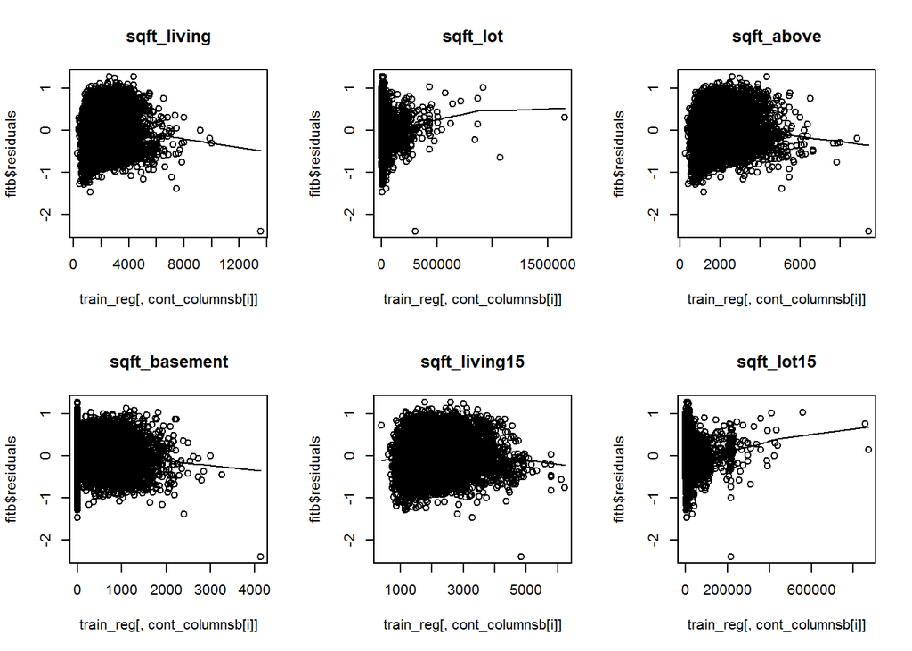

```r
par(mfrow=c(2,3))
for(i in 2:7) {
    plot(train_reg[,cont_columnsb[i]], fitb$residuals, main = names(train_reg[,cont_columnsb])[i])
    lines(lowess(train_reg[,cont_columnsb[i]], fitb$residuals))
}
```

We perform a regression using all variables, except, *id*, *date*, *zipcode*, *lat*, *long*, *date_day* and *date_month* as predictors for *price*.

```r
require(stats)
options(show.signif.stars = F)
fitc <- lm(log_price~.-price-date_day-date_month, data = train_reg)
summary(fitc)
```

```
Call:
lm(formula = log_price ~ . - price - date_day - date_month, data = train_reg)

Residuals:
     Min       1Q   Median       3Q      Max
-1.46503 -0.20336  0.01415  0.20442  1.30169

Coefficients: (1 not defined because of singularities)
                    Estimate     Std. Error t value             Pr(>|t|)
(Intercept)   11.25278640374  0.30735454890  36.612 < 0.0000000000000002
bedrooms      -0.02874030713  0.00344896093  -8.333 < 0.0000000000000002
bathrooms      0.07703130279  0.00595260621  12.941 < 0.0000000000000002
sqft_living    0.00018606239  0.00000789559  23.565 < 0.0000000000000002
sqft_lot       0.00000036063  0.00000009546   3.778             0.000159
floors         0.11297615719  0.00650936544  17.356 < 0.0000000000000002
waterfront1    0.34361728583  0.03489449004   9.847 < 0.0000000000000002
view1          0.14023157850  0.02112442589   6.638   0.0000000000328008
view2          0.07296744562  0.01258658551   5.797   0.0000000068761938
view3          0.08610479034  0.01704324283   5.052   0.0000004419962122
view4          0.19834872141  0.02596767923   7.638   0.0000000000000233
condition2     0.07190352892  0.08193081105   0.878             0.380168
condition3     0.27794991725  0.07750121623   3.586             0.000336
condition4     0.29704955274  0.07749783909   3.833             0.000127
condition5     0.36917748753  0.07785599167   4.742   0.0000021376389115
grade3        -0.48995421876  0.38399398322  -1.276             0.201995
grade4        -0.20349371015  0.32355916885  -0.629             0.529409
grade5        -0.06712314018  0.31711913662  -0.212             0.832371
grade6         0.13384296035  0.31682685738   0.422             0.672704
grade7         0.39725693974  0.31683243734   1.254             0.209920
grade8         0.61126738371  0.31691401612   1.929             0.053773
grade9         0.83414642234  0.31705175794   2.631             0.008523
grade10        0.98630336181  0.31727690255   3.109             0.001883
grade11        1.09702372414  0.31783230144   3.452             0.000559
grade12        1.19194526982  0.31996548954   3.725             0.000196
grade13        1.43900381081  0.33138300596   4.342   0.0000141840931147
sqft_above    -0.00007295191  0.00000782720  -9.320 < 0.0000000000000002
sqft_basement             NA             NA      NA                   NA
sqft_living15  0.00010801437  0.00000620701  17.402 < 0.0000000000000002
sqft_lot15    -0.00000057353  0.00000013821  -4.150   0.0000334599037582
date_year2015  0.03714343311  0.00535543120   6.936   0.0000000000042076
age            0.00579630536  0.00012381415  46.815 < 0.0000000000000002
renovated      0.01776726265  0.01340919874   1.325             0.185189

Residual standard error: 0.307 on 15097 degrees of freedom
Multiple R-squared:  0.6613,    Adjusted R-squared:  0.6606
F-statistic: 950.7 on 31 and 15097 DF,  p-value: < 0.00000000000000022
```

```r
null=lm(log_price~1, data=train_reg)
final_model <- step(null, scope = list(upper=fitc), data = train_reg, direction="both")
```

```
Start:  AIC=-19382.92
log_price ~ 1

                Df Sum of Sq    RSS    AIC
+ grade         11   2093.47 2107.5 -29797
+ sqft_living    1   2013.22 2187.7 -29252
+ sqft_living15  1   1610.26 2590.7 -26694
+ sqft_above     1   1510.89 2690.0 -26125
+ bathrooms      1   1275.96 2925.0 -24858
+ view           4    521.64 3679.3 -21381
+ bedrooms       1    474.85 3726.1 -21196
+ sqft_basement  1    421.01 3779.9 -20979
+ floors         1    396.32 3804.6 -20880
+ waterfront     1    139.63 4061.3 -19892
+ condition      4     66.21 4134.7 -19615
+ renovated      1     57.31 4143.6 -19589
+ sqft_lot       1     47.58 4153.3 -19553
+ sqft_lot15     1     35.98 4164.9 -19511
+ age            1     24.72 4176.2 -19470
<none>                       4200.9 -19383
+ date_year      1      0.32 4200.6 -19382

Step:  AIC=-29797.25
log_price ~ grade

                Df Sum of Sq    RSS    AIC
+ age            1    289.86 1817.6 -32034
+ sqft_living    1    238.01 1869.4 -31608
+ sqft_basement  1    172.22 1935.2 -31085
+ view           4    134.67 1972.8 -30788
+ sqft_living15  1    107.12 2000.3 -30584
+ condition      4     93.11 2014.4 -30473
+ waterfront     1     59.40 2048.1 -30228
+ bathrooms      1     53.56 2053.9 -30185
+ renovated      1     47.86 2059.6 -30143
+ bedrooms       1     41.58 2065.9 -30097
+ sqft_above     1     39.45 2068.0 -30081
+ date_year      1      2.85 2104.6 -29816
+ sqft_lot       1      1.71 2105.7 -29808
+ floors         1      0.65 2106.8 -29800
```

[output cut: 280 more lines]

```
+ renovated      1     0.165 1423.0 -35699
- sqft_lot       1     1.335 1424.5 -35687
- sqft_lot15     1     1.601 1424.8 -35684
- date_year      1     4.478 1427.6 -35653
- bedrooms       1     6.635 1429.8 -35631
- sqft_above     1     8.144 1431.3 -35615
- waterfront     1     9.358 1432.5 -35602
- view           4    12.671 1435.8 -35573
- condition      4    14.747 1437.9 -35551
- bathrooms      1    16.475 1439.6 -35527
- sqft_living15  1    28.414 1451.6 -35402
- floors         1    28.525 1451.7 -35401
- sqft_living    1    52.377 1475.5 -35154
- age            1   235.996 1659.2 -33380
- grade         11   295.231 1718.4 -32869
```

```r
summary(final_model)
```

```
Call:
lm(formula = log_price ~ grade + age + sqft_living + view + floors +
    sqft_living15 + bathrooms + condition + waterfront + sqft_above +
    bedrooms + date_year + sqft_lot15 + sqft_lot, data = train_reg)

Residuals:
     Min       1Q   Median       3Q      Max
-1.47031 -0.20341  0.01416  0.20458  1.30381

Coefficients:
                    Estimate     Std. Error t value             Pr(>|t|)
(Intercept)   11.25020490585  0.30735606496  36.603 < 0.0000000000000002
grade3        -0.49256968036  0.38399851870  -1.283             0.199603
grade4        -0.20731549766  0.32355440883  -0.641             0.521699
grade5        -0.07045988100  0.31711707285  -0.222             0.824170
grade6         0.13099799173  0.31682750987   0.413             0.679270
grade7         0.39461569191  0.31683409479   1.245             0.212969
grade8         0.60892758188  0.31691702663   1.921             0.054699
grade9         0.83192561020  0.31705526151   2.624             0.008701
grade10        0.98353329303  0.31727795415   3.100             0.001939
grade11        1.09361727310  0.31782985671   3.441             0.000581
grade12        1.18740889934  0.31995517868   3.711             0.000207
grade13        1.43460338551  0.33137465616   4.329   0.0000150582450698
age            0.00585029223  0.00011692092  50.036 < 0.0000000000000002
sqft_living    0.00018611999  0.00000789567  23.572 < 0.0000000000000002
view1          0.14098119495  0.02111737717   6.676   0.0000000000253988
view2          0.07298334943  0.01258689475   5.798   0.0000000068304851
view3          0.08665979959  0.01703852107   5.086   0.0000003698607146
view4          0.19842029579  0.02596827287   7.641   0.0000000000000229
floors         0.11320109803  0.00650731413  17.396 < 0.0000000000000002
sqft_living15  0.00010767946  0.00000620201  17.362 < 0.0000000000000002
bathrooms      0.07804507807  0.00590337795  13.220 < 0.0000000000000002
condition2     0.07316581231  0.08192732236   0.893             0.371841
condition3     0.28025183150  0.07748368098   3.617             0.000299
condition4     0.29819337267  0.07749497019   3.848             0.000120
condition5     0.36950734467  0.07785754193   4.746   0.0000020944117688
waterfront1    0.34684629278  0.03481015981   9.964 < 0.0000000000000002
sqft_above    -0.00007273864  0.00000782574  -9.295 < 0.0000000000000002
bedrooms      -0.02891613637  0.00344649335  -8.390 < 0.0000000000000002
date_year2015  0.03688856880  0.00535210973   6.892   0.0000000000057055
sqft_lot15    -0.00000056937  0.00000013817  -4.121   0.0000379831249337
sqft_lot       0.00000035929  0.00000009545   3.764             0.000168

Residual standard error: 0.307 on 15098 degrees of freedom
Multiple R-squared:  0.6612,    Adjusted R-squared:  0.6606
F-statistic: 982.3 on 30 and 15098 DF,  p-value: < 0.00000000000000022
```

```r
test$grade <- factor(test$grade, levels= final_model$xlevels$grade)
preds <- exp(predict(final_model, newdata=test))
actuals_preds <- data.frame(cbind(actuals=test$price, predicteds=preds))
actuals_preds <- na.omit(actuals_preds)
cor(actuals_preds)
```

```
             actuals predicteds
actuals    1.0000000  0.8161861
predicteds 0.8161861  1.0000000
```

Next, we will aim to explore possible interactions within the data set for inclusion. It will also be useful to use other regression methods such as ridge and lasso, and compare the results.